# Johnson_Nicholas.

### Test Items starts from here - There are 5 sections - 75 points total

##### Section 1: (15 points)

##### (1) R has probability functions available for use (Kabacoff, Section 5.2.3). Using one distribution to approximate another is not uncommon.

(1)(a) (6 points) The Poisson distribution may be used to approximate the binomial distribution if n > 20 and np < 7. Estimate the following binomial probabilities using *dpois()* or *ppois()* with probability p = 0.05, and n = 100. Then, estimate the same probabilities using *dbinom()* or *pbinom()*. Show the numerical results of your calculations.

1. The probability of exactly 0 successes.

```r
n <- 100
p <- 0.05
# only need 0, no subtraction for any value less than this
#np = 5, so less useful and not suggested, seems to be why they're different
ppois(0, lambda = n*p)
```

```
## [1] 0.006737947
```

```r
pbinom(0, n, p)
```

```
## [1] 0.005920529
```

```r
ppois(5, lambda = n*p)
```

```
## [1] 0.6159607
```

```r
pbinom(5, n, p)
```

```
## [1] 0.6159991
```

The binomial may also be approximated via the normal distribution. Estimate the following binomial probabilities using *dnorm()* or *pnorm()*, this time with probability p = 0.25 and n = 100. Then, calculate the same probabilities using *dbinom()* and *pbinom()*. Use continuity correction. Show the numerical results of your calculations.

3. The probability of exactly 25 successes.

```r
N <- 100
p <- 0.25
q <- 1-p
successes <- 25

#normal, need to use continuity correction going +- 0.5, find area between them
pnorm(successes+0.5, N*p, (N*p*q)^(0.5)) - pnorm(successes-0.5, N*p, (N*p*q)^(0.5))
```

```
## [1] 0.09192744
```

```r
#binomial, find for up to 25 success then take away the <=24 successes below that
dbinom(successes, N, p)#pbinom - pbinom(successes - 1, N, p)
```

```
## [1] 0.09179969
```

```r
successes <- 19

#normal, using continuity we go for left side of 20-0.5, less than 20 (here 19+0.5)
pnorm(successes+0.5, N*p, (N*p*q)^(0.5))
```

```
## [1] 0.1020119
```

```r
#binomial, find for up to 19 successes, less than 20
pbinom(successes, N, p)
```

```
## [1] 0.09953041
```

(1)(b) (3 points) Generate side-by-side barplots using *par(mfrow = c(1,2))* or *grid.arrange()*. The left barplot will show Poisson probabilties for outcomes ranging from 0 to 10. The right barplot will show binomial probabilities for outcomes ranging from 0 to 10. Use p = 0.05 and n = 100. Title each plot, present in color and assign names to the bar; i.e. x-axis value labels.

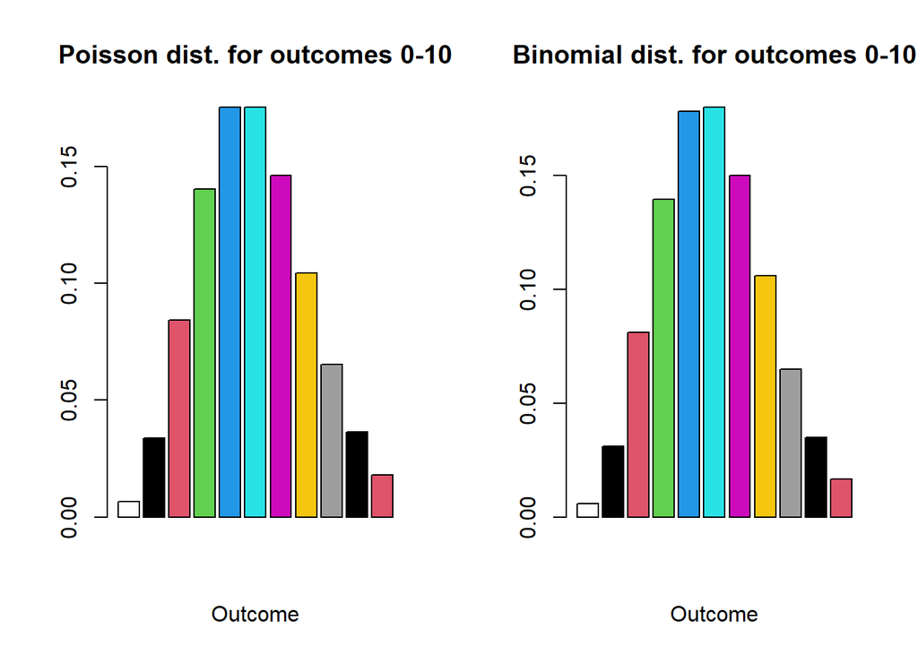

```r
par(mfrow = c(1,2))
n <- 100
p <- 0.05
x <- 0:10

#left, Poisson
barplot(dpois(x, lambda = n*p), main = "Poisson dist. for outcomes 0-10", xlab = "Outcome", col = x)

#right, Binomial
barplot(dbinom(x, n, p), main = "Binomial dist. for outcomes 0-10", xlab = "Outcome", col = x)
```

```r
par(mfrow = c(1,1))
```

1. Calculate the expected value and variance for this distribution using the general formula for mean and variance of a discrete distribution. To do this, you will need to use integer values from 0 to 6 as outcomes along with the corresponding probabilities. Round your answer to 2 decimal places.

```r
x <- 0:6
x_prob <- c(0.214, 0.230, 0.240, 0.182, 0.130, 0.003, 0.001)
mu <- sum(x * x_prob)
paste('expected_value:', round(mu,2))
```

```
## [1] "expected_value: 1.8"
```

```r
#variance = sum(difference from mean squared times percentage of that sample)
var <- 0
for(i in x){
  diff <- x[i+1] - mu
  var <- var + diff^2 * x_prob[i+1]
}
paste('variance:',round(var,2))
```

```
## [1] "variance: 1.79"
```

2. Use the *cumsum()* function and plot the cumulative probabilties versus the corresponding outcomes. Detemine the value of the median for this distribution and show on this plot. Note that there are methods for interpolating a median. However, we can identify an appropriate median from our set of our outcomes - 0 through 6 - that satisfies the definition. Creating a stair-step plot of the cumulative probability as a function of the outcomes may be helpful in identifying it.

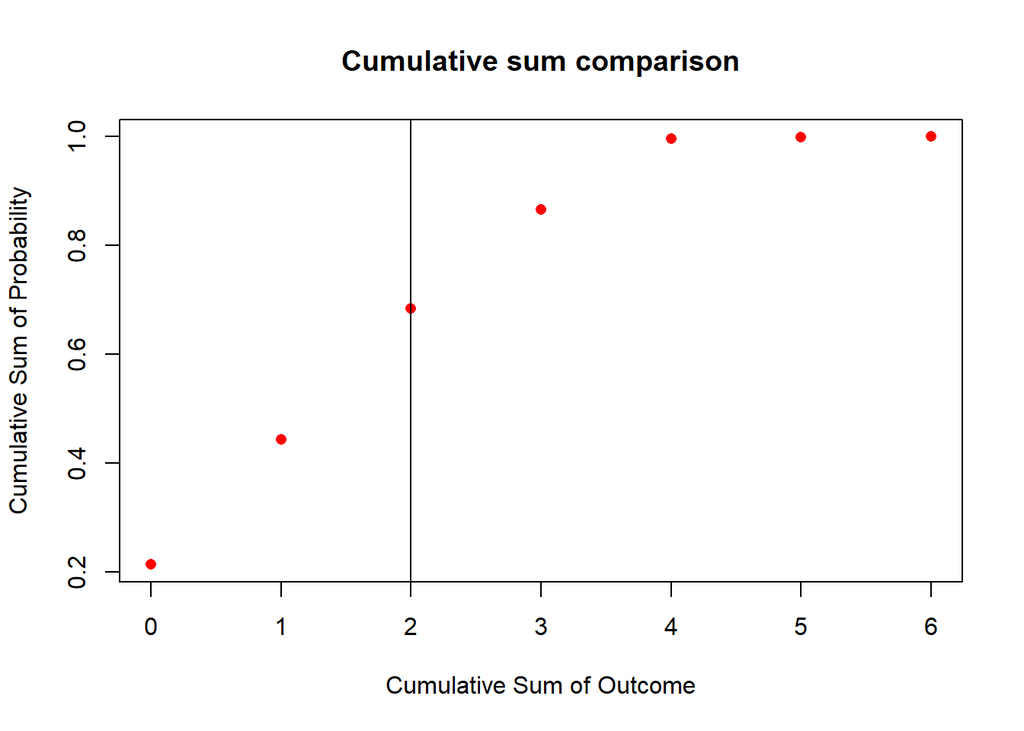

```r
plot(cumsum(x_prob) ~ x, main = 'Cumulative sum comparison', xlab = 'Cumulative Sum of Outcome', ylab = 'Cumulative Sum of Probability', col = 'red', pch = 16)
#median = where it goes from <.50 to >.50
abline(v = 2)
```

##### Section 2: (15 points)

##### (2) Conditional probabilities appear in many contexts and, in particular, are used by Bayes' Theorem. Correlations are another means for evaluating dependency between variables. The dataset "faithful"" is part of the "datasets" package and may be loaded with the statement *data(faithful)*. It contains 272 observations of 2 variables; waiting time between eruptions (in minutes) and the duration of the eruption (in minutes) for the Old Faithful geyser in Yellowstone National Park.

(2)(a) (6 points) Load the "faithful" dataset and present summary statistics and a histogram of waiting times. Additionally, compute the empirical conditional probability of an eruption less than 3.0 minutes, if the waiting time exceeds 70 minutes.

```r
data(faithful, package = "datasets")
summary(faithful)
```

```
##    eruptions        waiting
##  Min.   :1.600   Min.   :43.0
##  1st Qu.:2.163   1st Qu.:58.0
##  Median :4.000   Median :76.0
##  Mean   :3.488   Mean   :70.9
##  3rd Qu.:4.454   3rd Qu.:82.0
##  Max.   :5.100   Max.   :96.0
```

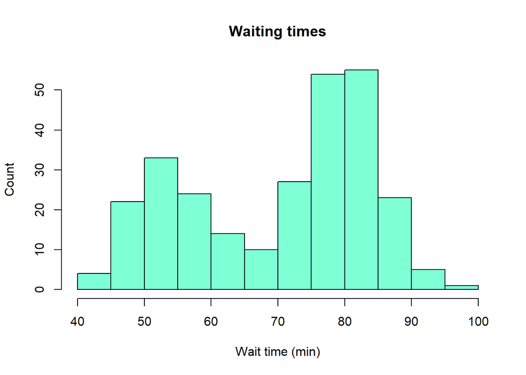

```r
hist(faithful$waiting, main = 'Waiting times', ylab = 'Count', xlab = 'Wait time (min)', col = 'aquamarine')
```

```r
over_70 <- nrow(faithful[faithful$waiting > 70,])
and_under_3 <- nrow(faithful[faithful$waiting > 70 & faithful$eruptions < 3.0,])

paste('Empirical conditional probability of eruption < 3.0min, if waiting time > 70min:' ,round(and_under_3 / over_70,4))
```

```
## [1] "Empirical conditional probability of eruption < 3.0min, if waiting time > 70min: 0.0061"
```

1. Identify any observations in "faithful" for which the waiting time exceeds 70 minutes and the eruptions are less than 3.0 minutes. List and show any such observations in a distinct color on a scatterplot of all eruption (vertical axis) and waiting times (horizontal axis). Include a horizontal line at eruption = 3.0, and a vertical line at waiting time = 70. Add a title and appropriate text.

```r
faithful[(faithful$waiting > 70 & faithful$eruptions < 3.0),]
```

```
##     eruptions waiting
## 211     2.383      71
```

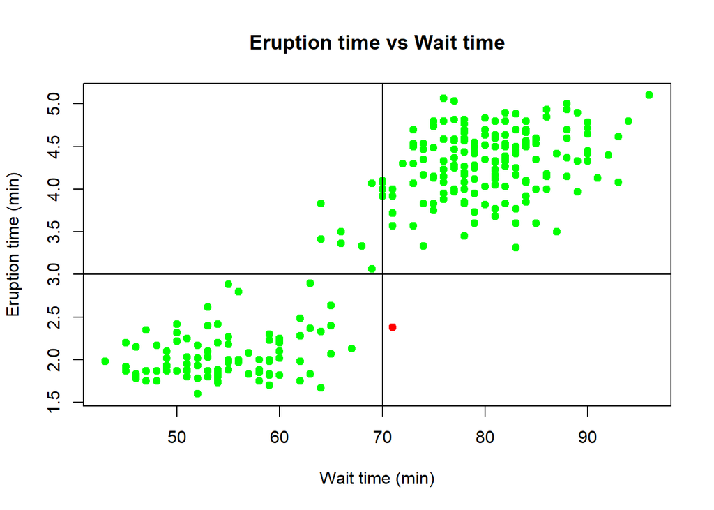

```r
plot(faithful$eruptions ~ faithful$waiting, main = 'Eruption time vs Wait time', ylab = 'Eruption time (min)', xlab = 'Wait time (min)', col = ifelse(faithful$waiting > 70 & faithful$eruptions < 3.0, 'red', 'green'), pch = 19)
abline(h = 3.0)
abline(v = 70)
```

2. What does the plot suggest about the relationship between eruption time and waiting time?

*Answer: There is a generally linear correlation between wait time and eruption, which could make some sense as the gases build up over time. If the gases build up for a short time, there is a short eruption, whereas a longer buildup leads to a greater eruption. This is not a perfect linear correlation however, with outliers including the one we noted.*

(2)(b) (6 points) Past research indicates that the waiting times between consecutive eruptions are not independent. This problem will check to see if there is evidence of this. Form consecutive pairs of waiting times. In other words, pair the first and second waiting times, pair the third and fourth waiting times, and so forth. There are 136 resulting consecutive pairs of waiting times. Form a data frame with the first column containing the first waiting time in a pair and the second column with the second waiting time in a pair. Plot the pairs with the second member of a pair on the vertical axis and the first member on the horizontal axis.

One way to do this is to pass the vector of waiting times - faithful$waiting - to *matrix()*, specifying 2 columns for our matrix, with values organized by row; i.e. byrow = TRUE.

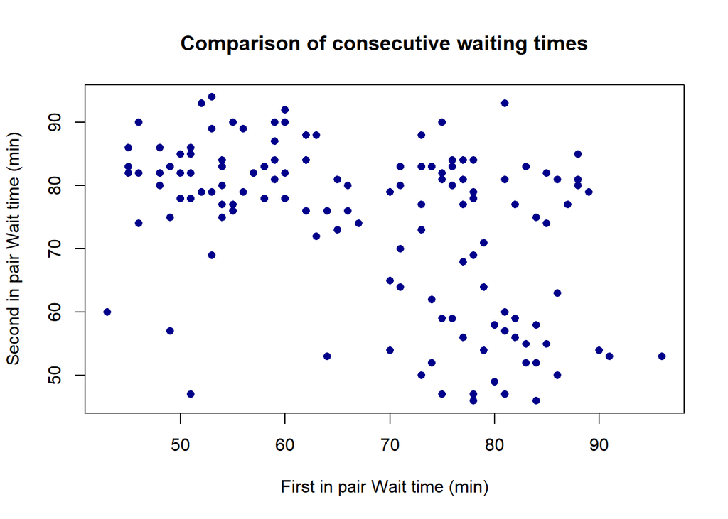

```r
m <- matrix(faithful$waiting, ncol = 2, byrow = TRUE)
plot(m[,2] ~ m[,1], main = 'Comparison of consecutive waiting times', xlab = 'First in pair Wait time (min)', ylab =  'Second in pair Wait time (min)', pch = 16, col = 'darkblue')
```

(2)(c) (3 points) Test the hypothesis of independence with a two-sided test at the 5% level using the Kendall correlation coefficient. The *cor.test()* function can be used to structure this test and specify the appropriate - Kendall's tau - method.

```r
cor.test(m[,1], m[,2], method = "kendall", conf.level = 0.95, alternative = 'two.sided')
```

```
##
##  Kendall's rank correlation tau
##
## data:  m[, 1] and m[, 2]
## z = -4.9482, p-value = 7.489e-07
## alternative hypothesis: true tau is not equal to 0
## sample estimates:
##        tau
## -0.2935579
```

##### Section 3: (15 points)

##### (3) Performing hypothesis tests using random samples is fundamental to statistical inference. The first part of this problem involves comparing two different diets. Using "ChickWeight" data available in the base R, "datasets" package, we will create a subset of the "ChickWeight" data frame. Specifically, we want to create a data frame that includes only those rows where Time == 21 AND Diet == 1 or 3.

```r
# load "ChickWeight" dataset
data(ChickWeight, package = "datasets")

# There are multiple ways to approach the subsetting task. The method you choose is up
# to you.
result <- ChickWeight[ChickWeight$Time == 21 & (ChickWeight$Diet == 1 | ChickWeight$Diet == 3),]
#head(result)

# The values in your subsetted data frame should match those below:
# > head(df)
#    weight Time Chick Diet
# 12    205   21     1    1
# 24    215   21     2    1
# 36    202   21     3    1
# 48    157   21     4    1
# 60    223   21     5    1
# 72    157   21     6    1
```

##### The data frame, "result", has chick weights for two diets, identified as diet "1" and "3". Use the data frame, "result," to complete the following item.

(3)(a) (3 points) Display two side-by-side vertical boxplots using par(mfrow = c(1,2)). One boxplot would display Diet "1" and the other Diet "3".

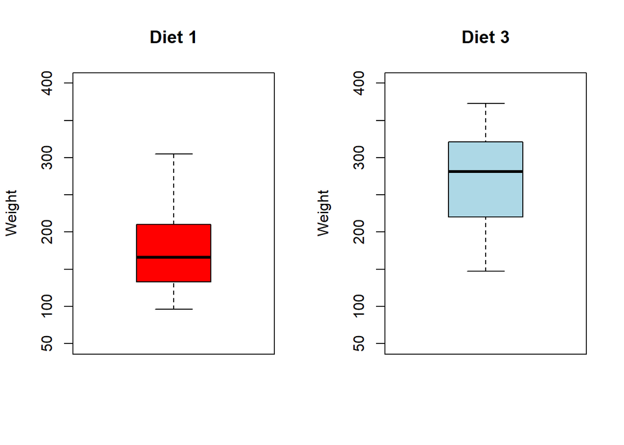

```r
par(mfrow = c(1,2))

boxplot(result$weight[result$Diet == 1], main = 'Diet 1', col = 'red', ylab = 'Weight', ylim = c(50,400))
boxplot(result$weight[result$Diet == 3], main = 'Diet 3', col = 'light blue', ylab = 'Weight', ylim = c(50,400))
```

```r
par(mfrow = c(1,1))
```

```r
t.test(result$weight[result$Diet == 1], result$weight[result$Diet == 3], alternative = 'two.sided', conf.level = 0.95)
```

```
##
##  Welch Two Sample t-test
##
## data:  result$weight[result$Diet == 1] and result$weight[result$Diet == 3]
## t = -3.4293, df = 16.408, p-value = 0.003337
## alternative hypothesis: true difference in means is not equal to 0
## 95 percent confidence interval:
##  -149.64644  -35.45356
## sample estimates:
## mean of x mean of y
##    177.75    270.30
```

##### Working with paired data is another common statistical activity. The "ChickWeight" data will be used to illustrate how the weight gain from day 20 to 21 may be analyzed. This time, we will look only at those individuals on Diet == "3". You will need to add code below creating two (2) vectors. One (1) vector should include all the Time == 20 weights of those individuals on Diet == "3"; a second should include all the Time == 21 weights of those individuals on Diet == "3".

```r
# There are multiple ways to approach the subsetting task. The method you choose is up
# to you.

vec20 <- ChickWeight$weight[ChickWeight$Time == 20 & ChickWeight$Diet == 3]
vec21 <- ChickWeight$weight[ChickWeight$Time == 21 & ChickWeight$Diet == 3]


# The first six (6) elements of your Time == 20 vector should match those below:
# [1] 235 291 156 327 361 225
```

(3)(c) (3 points) Present a scatterplot of the Time == 21 weights as a function of the Time == 20 weights. Include a diagonal line with zero intercept and slope equal to one. Title and label the variables in this scatterplot.

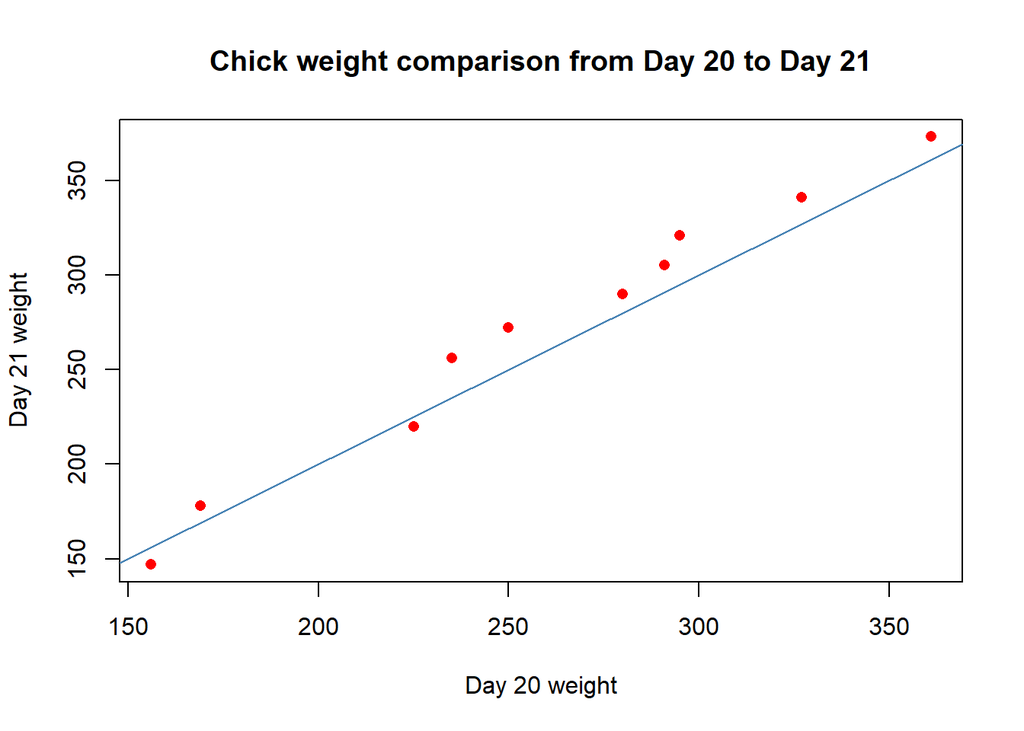

```r
plot(vec21 ~ vec20, main = 'Chick weight comparison from Day 20 to Day 21', pch = 16, xlab = 'Day 20 weight', ylab = 'Day 21 weight', col = 'red')
abline(a = 0, b = 1, col = 'steelblue')
```

(3)(d) (6 points) Calculate and present a one-sided, 95% confidence interval for the average weight gain from day 20 to day 21. Write the code for the paired t-test and for determination of the confidence interval endpoints. **Do not use *t.test()**, although you may check your answers using this function. Present the resulting test statistic value, critical value, p-value and confidence interval.

```r
x <- vec20
y <- vec21

n <- length(x)
df <- n-1
paste0('degrees of freedom: ',df)
```

```
## [1] "degrees of freedom: 9"
```

```r
conf.int <- 0.95

diff <- x-y
mean_diff <- mean(diff)
stddev_diff <- sd(diff)

test_diff <- 0 #No mean weight gained between the two days, testing Alternative Hypothesis weight is gained diff > 0

t <- (mean_diff - test_diff) / (stddev_diff / n^.5)
paste0('t: ',t)
```

```
## [1] "t: -3.22526710814625"
```

```r
crit_val <- qt((1-conf.int)/2, df)
paste0('critical values: ', crit_val, ', ', -crit_val)
```

```
## [1] "critical values: -2.2621571627982, 2.2621571627982"
```

```r
error_margin <- crit_val * stddev_diff / n^.5

end1 <- mean_diff - error_margin
end2 <- mean_diff + error_margin
paste0('95% confidence interval: ', round(end2,4), ' to ', round(end1,4))
```

```
## [1] "95% confidence interval: -19.3958 to -3.4042"
```

```r
p_val <- pt(t, df)
paste0('p-value: ', round(p_val,4))
```

```
## [1] "p-value: 0.0052"
```

##### Section 4: (15 points)

##### (4) Statistical inference depends on using a sampling distribution for a statistic in order to make confidence statements about unknown population parameters. The Central Limit Theorem is used to justify use of the normal distribution as a sampling distribution for statistical inference. Using Nile River flow data from 1871 to 1970, this problem demonstrates sampling distribution convergence to normality. Use the code below to prepare the data. Refer to this example when completing (4)(c) below.

```r
data(Nile, package = "datasets")
```

(4)(a) (3 points) Using Nile River flow data and the "moments" package, calculate skewness and kurtosis. Present a QQ plot and boxplot of the flow data side-by-side using *qqnorm()*, *qqline()* and *boxplot()*; *par(mfrow = c(1, 2))* may be used to locate the plots side-by-side. Add features to these displays as you choose.

```r
paste0('skewness: ', skewness(Nile))
```

```
## [1] "skewness: 0.322369681723753"
```

```r
paste0('kurtosis: ', kurtosis(Nile))
```

```
## [1] "kurtosis: 2.69509315497952"
```

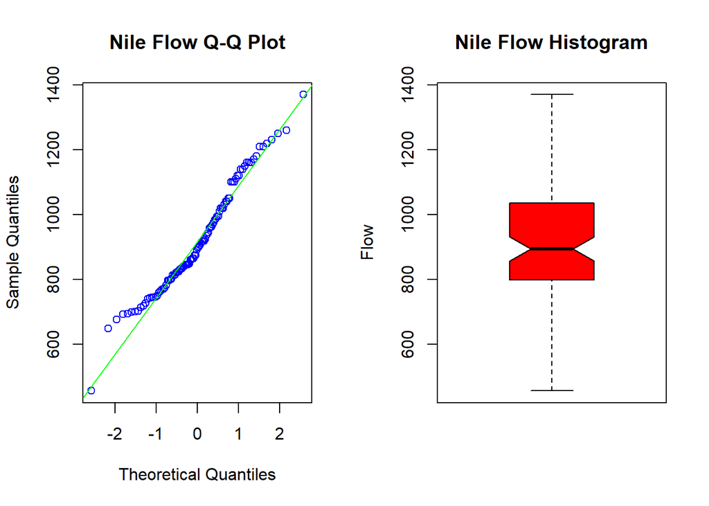

```r
par(mfrow = c(1,2))
qqnorm(Nile, main = 'Nile Flow Q-Q Plot', col = 'blue')
qqline(Nile, col = 'green')
boxplot(Nile, main = 'Nile Flow Histogram', col = 'red', ylab = 'Flow', notch = TRUE)
```

```r
par(mfrow = c(1,1))
```

(4)(b) (6 points) Using *set.seed(124)* and the Nile data, generate 1000 random samples of size n = 16, with replacement. For each sample drawn, calculate and store the sample mean. This can be done with a for-loop and use of the *sample()* function. Label the resulting 1000 mean values as "sample1". **Repeat these steps using *set.seed(127)* - a different "seed" - and samples of size n = 64.** Label these 1000 mean values as "sample2". Compute and present the means, sample standard deviations and sample variances for "sample1" and "sample2" in a table with the first row for "sample1", the second row for "sample2" and the columns labled for each statistic.

```r
set.seed(124)
sample1 <- NULL
for(i in 1:1000){sample1<- c(sample1, mean(sample(Nile, 16, replace = TRUE)))}

set.seed(127)
sample2 <- NULL
for(i in 1:1000){sample2<- c(sample2, mean(sample(Nile, 64, replace = TRUE)))}

mean1 <- mean(sample1)
sd1 <- sd(sample1)
var1 <- var(sample1)
mean2 <- mean(sample2)
sd2 <- sd(sample2)
var2 <- var(sample2)

row_names <- c("sample1", "sample2")
col_names <- c("Mean", "Sample std dev", "Sample variance")

matrix(c(mean1, sd1, var1, mean2, sd2, var2), nrow = 2, byrow = TRUE, dimnames = list(row_names, col_names))
```

```
##             Mean Sample std dev Sample variance
## sample1 918.7364       42.00156       1764.1312
## sample2 918.5149       20.22883        409.2054
```

(4)(c) (6 points) Present side-by-side histograms of "sample1" and "sample2" with the normal density curve superimposed. To prepare comparable histograms, it will be necessary to use "freq = FALSE" and to maintain the same x-axis with "xlim = c(750, 1050)", and the same y-axis with "ylim = c(0, 0.025)." **To superimpose separate density functions, you will need to use the mean and standard deviation for each "sample" - each histogram - separately.**

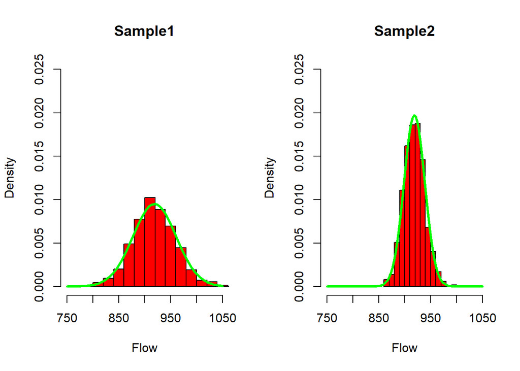

```r
# Create histograms of "sample1" and "sample2" with normal density curves superimposed
par(mfrow = c(1,2))


m <- mean(sample1)
stddev <- sd(sample1)
hist(sample1, freq = FALSE, main = 'Sample1', col = 'red', xlab = 'Flow', xlim = c(750, 1050), ylim = c(0, 0.025))
curve(dnorm(x, mean = m, sd = stddev), add = TRUE, col = 'green', lwd = 3)

m <- mean(sample2)
stddev <- sd(sample2)
hist(sample2, freq = FALSE, main = 'Sample2', col = 'red', xlab = 'Flow', xlim = c(750, 1050), ylim = c(0, 0.025))
curve(dnorm(x, mean = m, sd = stddev), add = TRUE, col = 'green', lwd = 3)
```

```r
par(mfrow = c(1,1))
```

##### Section 5: (15 points)

##### (5) This problem deals with contingency table analysis. This is an example of categorical data analysis (see Kabacoff, pp. 145-151). The "warpbreaks" dataset gives the number of warp breaks per loom, where a loom corresponds to a fixed length of yarn. There are 54 observations on 3 variables: breaks (numeric, the number of breaks), wool (factor, type of wool: A or B), and tension (factor, low L, medium M and high H). These data have been studied and used for example elsewhere. For the purposes of this problem, we will focus on the relationship between breaks and tension using contingency table analysis.

(5)(a)(5 points) warpbreaks is part of the "datasets" package and may be loaded via *data(warpbreaks)*. Load "warpbreaks" and present the structure using *str()*. Calculate the median number of breaks for the entire dataset, disregarding "tension" and "wool". Define this median value as "median_breaks". Present a histogram of the number of breaks with the location of the median indicated.

Create a new variable "number" as follows: for each value of "breaks", classify the number of breaks as either strictly below "median_breaks", or the alternative. Convert the "above"|"below" classifications to a factor, and combine with the dataset warpbreaks. Present a summary of the augmented dataset using *summary()*. Present a contingency table of the frequency of breaks using the two variables "tension" and "number". There should be six cells in this table.

```r
data(warpbreaks, package = "datasets")
str(warpbreaks)
```

```
## 'data.frame':    54 obs. of  3 variables:
##  $ breaks : num  26 30 54 25 70 52 51 26 67 18 ...
##  $ wool   : Factor w/ 2 levels "A","B": 1 1 1 1 1 1 1 1 1 1 ...
##  $ tension: Factor w/ 3 levels "L","M","H": 1 1 1 1 1 1 1 1 1 2 ...
```

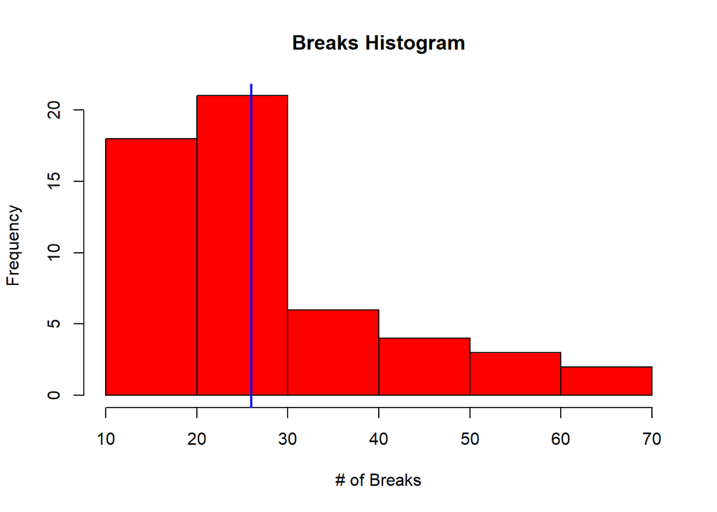

```r
median_breaks <- median(warpbreaks$breaks)
hist(warpbreaks$breaks, col = 'red', main = 'Breaks Histogram', xlab = '# of Breaks')
abline(v = median_breaks, col = 'blue', lwd = 2)
```

```r
number <- as.factor(ifelse(warpbreaks$breaks<median_breaks, 'below', 'above'))
new_warp <- cbind(warpbreaks, number)
summary(new_warp)
```

```
##      breaks      wool   tension   number
##  Min.   :10.00   A:27   L:18    above:29
##  1st Qu.:18.25   B:27   M:18    below:25
##  Median :26.00          H:18
##  Mean   :28.15
##  3rd Qu.:34.00
##  Max.   :70.00
```

```r
warp2_table <- table(new_warp$tension, new_warp$number)
warp2_table
```

```
##
##     above below
##   L    14     4
##   M    10     8
##   H     5    13
```

(5)(b)(3 points) Using the table constructed in (5)(a), test at the 5% level the null hypothesis of independence using the uncorrected *chisq.test()* (Black, Business Statistics, Section 16.2). Show the results of this test and state your conclusions.

```r
chisq.test(warp2_table)
```

```
##
##  Pearson's Chi-squared test
##
## data:  warp2_table
## X-squared = 9.0869, df = 2, p-value = 0.01064
```

```r
paste0('Using alpha = 0.05, we would reject the null hypothesis (independent variables) with a p-value of 0.01064 as evidence of a statistically significant result, instead favoring the alternative hypothesis that tension and number are related (dependent).')
```

```
## [1] "Using alpha = 0.05, we would reject the null hypothesis (independent variables) with a p-value of 0.01064 as evidence of a statistically significant result, instead favoring the alternative hypothesis that tension and number are related (dependent)."
```

(5)(c) (3 points) 'Manually' calculate the chi-squared statistic and p-value of the table from (5)(a). The *addmargins()* function can be used to add row and column sums to the table; useful for calculating the expected values for each cell. You should be able to match the chi-squared and p-values from (5)(b). The underlying code for the *chisq.test()* function can be viewed by entering *chisq.test* - without parentheses - in the Console. You are given code below to create the table, add row and column sums and calculate the expected values for the for the first two (2) of three (3) rows. You will need to add code to calculate the expected values for the third row and the chi-squared. The *pchisq()* function can be used to return the p-value.

```r
tbl <- table(new_warp$tension, new_warp$number)
mar_tbl <- addmargins(tbl)

df <- 2

e11 <- mar_tbl[4, 1] * mar_tbl[1, 3] / mar_tbl[4, 3]
e12 <- mar_tbl[4, 2] * mar_tbl[1, 3] / mar_tbl[4, 3]
e21 <- mar_tbl[4, 1] * mar_tbl[2, 3] / mar_tbl[4, 3]
e22 <- mar_tbl[4, 2] * mar_tbl[2, 3] / mar_tbl[4, 3]
e32 <- mar_tbl[4, 2] * mar_tbl[3, 3] / mar_tbl[4, 3]
e31 <- mar_tbl[4, 1] * mar_tbl[3, 3] / mar_tbl[4, 3]

chisq <- (mar_tbl[1,1] - e11)^2 / e11 +
  (mar_tbl[1,2] - e12)^2 / e12 +
  (mar_tbl[2,1] - e21)^2 / e21 +
  (mar_tbl[2,2] - e22)^2 / e22 +
  (mar_tbl[3,1] - e31)^2 / e31 +
  (mar_tbl[3,2] - e32)^2 / e32
paste0('Chi-square value: ',round(chisq,4))
```

```
## [1] "Chi-square value: 9.0869"
```

```r
paste0('p-value: ', round(pchisq(chisq, df,lower.tail = FALSE),4))
```

```
## [1] "p-value: 0.0106"
```

(5)(d) (4 points) Build a user-defined function, using your code for (5)(c).We want to pass our (5)(a) table to our function and have it return the chi-squared statistic and p-value. You're provided with the 'shell' of a function and will need to add code to calculate the expected values, the chi-squared statistic, the p-value and return (i.e. output) the chi-squared and p-value.

```r
chisq_function <- function(x) {
  # Code for calculating the expected values
  mar_tbl <- addmargins(x)
  e11 <- mar_tbl[4, 1] * mar_tbl[1, 3] / mar_tbl[4, 3]
  e12 <- mar_tbl[4, 2] * mar_tbl[1, 3] / mar_tbl[4, 3]
  e21 <- mar_tbl[4, 1] * mar_tbl[2, 3] / mar_tbl[4, 3]
  e22 <- mar_tbl[4, 2] * mar_tbl[2, 3] / mar_tbl[4, 3]
  e32 <- mar_tbl[4, 2] * mar_tbl[3, 3] / mar_tbl[4, 3]
  e31 <- mar_tbl[4, 1] * mar_tbl[3, 3] / mar_tbl[4, 3]

  rows <- nrow(x)
  cols <- ncol(x)


  # Code for calculating the chi-squared
  chisq <- (mar_tbl[1,1] - e11)^2 / e11 +
           (mar_tbl[1,2] - e12)^2 / e12 +
           (mar_tbl[2,1] - e21)^2 / e21 +
           (mar_tbl[2,2] - e22)^2 / e22 +
           (mar_tbl[3,1] - e31)^2 / e31 +
           (mar_tbl[3,2] - e32)^2 / e32

  # Code for calculating the degrees of freedom and p-value
  df <- (cols - 1)*(rows - 1)
  p_val <- pchisq(chisq, df,lower.tail = FALSE)


  # Code to ouput the chi-squared, degrees of freedom and p-value
  return(cat(sprintf("chi-square: %.4f\ndf: %d\np-value: %.5f", chisq, df, p_val)))
}

chisq_function(tbl)
```

```
## chi-square: 9.0869
## df: 2
## p-value: 0.01064
```

You do not need to do anything with the below. It is provided only for demonstration purposes. In (5)(d), we know the size of the table - 3 x 2 - and write a function to match. Often, though, we'll want to write functions that are flexible in some way.

```r
# Below is a function that should return the same values as chisq.test() and your
# function from (5)(d). Here, though, the function loops over the rows and columns
# to calculate the expected values. Ideally, this function would work for any sized
# table.

#chisqfun <- function(t) {
#   x <- addmargins(t)
#   e <- matrix(0, nrow = nrow(t), ncol = ncol(t), byrow = T)
#   r <- matrix(0, nrow = nrow(t), ncol = ncol(t), byrow = T)
#   for (i in 1:dim(t)[1]) {
#       for (j in 1:dim(t)[2]) {
#          e[i,j] = x[nrow(x),j] * x[i,ncol(x)]/x[nrow(x), ncol(x)]
#         r[i,j] = ((x[i,j] - e[i,j])^2)/e[i,j]
#         }
#     }
#  chi <- sum(r)
#  xdf <- (nrow(t) - 1) * (ncol(t) - 1)
#  pv <- pchisq(chi, df = xdf, lower.tail = FALSE)
#  return(list("chi-squared" = chi, "degrees_of_freedom" = xdf, "p-value" = pv))
#  }
#
```